# EDA-1

In this cell, the required libraries are imported, such as requests for making HTTP requests, BeautifulSoup for parsing HTML, matplotlib for creating plots, and nltk and TextBlob for natural language processing tasks.

```python
import requests
from bs4 import BeautifulSoup

from collections import Counter
import matplotlib.pyplot as plt
from wordcloud import WordCloud

import nltk
nltk.download('stopwords')
nltk.download('punkt')

from textblob import TextBlob
from nltk.corpus import stopwords
```

This cell is responsible for making a GET request to the specified URL and parsing the HTML content using BeautifulSoup. The cell then extracts all header tags (h1, h2, h3, h4, h5, h6) and appends them to the 'headers' list.

```python
url = 'https://hindenburgresearch.com/adani/'
response = requests.get(url)
soup = BeautifulSoup(response.text, 'html.parser')

# Extract all headers
headers = []
for header in soup.find_all(['h1', 'h2', 'h3', 'h4', 'h5', 'h6']):
    headers.append(header.text.strip())
```

This cell extracts text from various HTML tags (div, p, and li) and appends them to their respective lists. It also extracts all the links (a tags with href attribute) from the HTML content and appends them to the 'links' list. Finally, it prints the lists containing headers, divs, paragraphs, and links.

```python
# Extract all div tags
divs = []
for div in soup.find_all('div'):
    divs.append(div.text.strip())

# Extract all p tags
paragraphs = []
for paragraph in soup.find_all('p'):
    paragraphs.append(paragraph.text.strip())
li = []
for l in soup.find_all('li'):
    li.append(l.text.strip())

# Extract all links
links = []
for link in soup.find_all('a'):
    href = link.get('href')
    if href is not None:
        links.append(href)

# Print the results
# print('Headers:', headers)
# print('Divs:', divs)
# print('Paragraphs:', paragraphs)
# print('Links:', links)
# print('\n\n\nLi:',li)
```

In this cell, the extracted paragraphs are preprocessed, and a word cloud and a list of the most common words are generated. This cell focuses on the content inside the 'p' tags.

```
Most common words:
adani: 588
group: 184
pg: 109
companies: 103
entities: 99
enterprises: 82
us: 77
listed: 75
investment: 74
power: 70
```

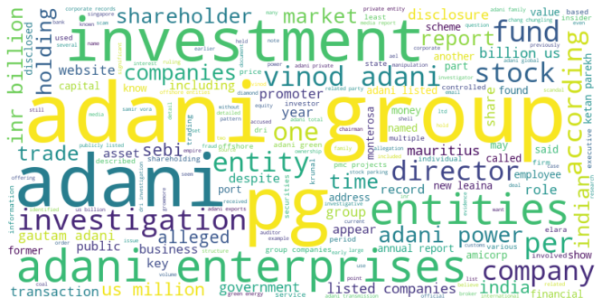

```python
# Extracting paragraphs
paragraphs = []
for paragraph in soup.find_all('p'):
    paragraphs.append(paragraph.text.strip())

# Concatenating paragraphs into a single string
text = ' '.join(paragraphs)

# Preprocessing the text data
text = text.lower()
text = ''.join(c for c in text if c.isalnum() or c.isspace())
words = text.split()
stop_words = set(stopwords.words('english'))
words = [word for word in words if word not in stop_words]

# Performing text analysis
#words = text.split()
word_count = Counter(words)

# Printing the most common words
print('Most common words:')
for word, count in word_count.most_common(10):
    print(f'{word}: {count}')

# Creating a word cloud
wordcloud = WordCloud(width=800, height=400, background_color='white').generate(text)
plt.figure(figsize=(12, 6))
plt.imshow(wordcloud, interpolation='bilinear')
plt.axis('off')
plt.show()
```

This cell performs the same tasks as the previous cell, but it focuses on the content inside the 'li' tags.

```
Most common words:
Adani: 227
entities: 47
Vinod: 43
What: 40
entity: 38
listed: 37
private: 31
Group: 27
The: 27
Adani’s: 25
```

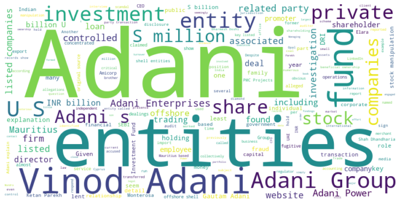

```python
# Extracting paragraphs
paragraphs = []
for paragraph in soup.find_all('li'):
    paragraphs.append(paragraph.text.strip())

# Concatenating paragraphs into a single string
text = ' '.join(paragraphs)
words = text.split()
stop_words = set(stopwords.words('english'))
words = [word for word in words if word not in stop_words]

# Performing text analysis
#words = text.split()
word_count = Counter(words)

# Printing the most common words
print('Most common words:')
for word, count in word_count.most_common(10):
    print(f'{word}: {count}')

# Creating a word cloud
wordcloud = WordCloud(width=800, height=400, background_color='white').generate(text)
plt.figure(figsize=(12, 6))
plt.imshow(wordcloud, interpolation='bilinear')
plt.axis('off')
plt.show()
```

This cell performs the same tasks as the previous cells, but it focuses on the content inside the header tags (h1, h2, h3, h4, h5, h6).

```
Most common words:
Adani: 113
The: 100
Of: 81
In: 69
A: 63
To: 61
And: 56
Money: 37
Group: 34
Entities: 29
```

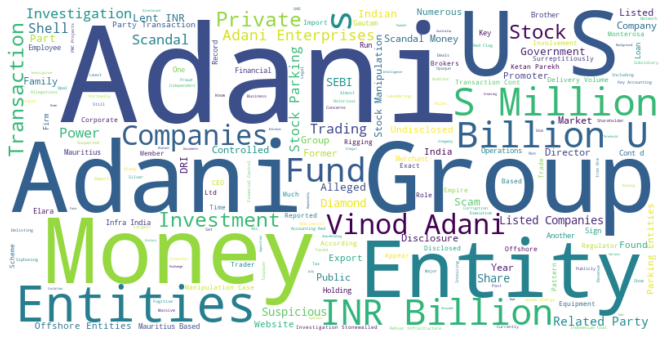

```python
# Extracting paragraphs
paragraphs = []
for paragraph in soup.find_all(['h1', 'h2', 'h3', 'h4', 'h5', 'h6']):
    paragraphs.append(paragraph.text.strip())

# Concatenating paragraphs into a single string
text = ' '.join(paragraphs)
words = text.split()
stop_words = set(stopwords.words('english'))
words = [word for word in words if word not in stop_words]

# Performing text analysis
#words = text.split()
word_count = Counter(words)

# Printing the most common words
print('Most common words:')
for word, count in word_count.most_common(10):
    print(f'{word}: {count}')

# Creating a word cloud
wordcloud = WordCloud(width=800, height=400, background_color='white').generate(text)
plt.figure(figsize=(12, 6))
plt.imshow(wordcloud, interpolation='bilinear')
plt.axis('off')
plt.show()
```

This cell performs the same tasks as the previous cells, but it focuses on the content inside the 'div' tags.

```python
# Extracting paragraphs
paragraphs = []
for paragraph in soup.find_all('div'):
    paragraphs.append(paragraph.text.strip())

# Concatenating paragraphs into a single string
text = ' '.join(paragraphs)
words = text.split()
stop_words = set(stopwords.words('english'))
words = [word for word in words if word not in stop_words]

# Performing text analysis
#words = text.split()
word_count = Counter(words)

word_count = Counter(words)

# Printing the most common words
print('Most common words:')
for word, count in word_count.most_common(10):
    print(f'{word}: {count}')
```

```
Most common words:
Adani: 2653
The: 717
Group: 533
[Pg.: 427
In: 400
entities: 378
Vinod: 373
listed: 337
INR: 315
A: 267
```

In this cell, a word cloud is generated based on the content extracted from 'div' tags.

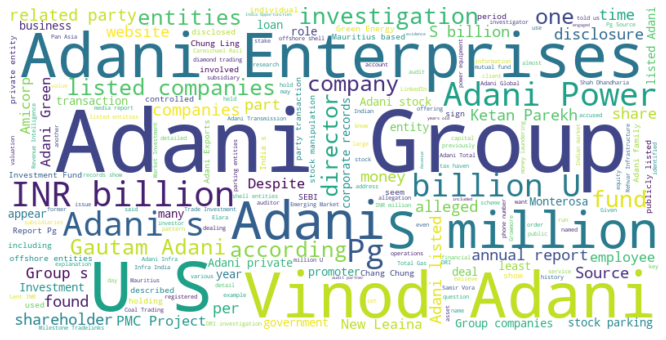

```python
# Creating a word cloud
wordcloud = WordCloud(width=800, height=400, background_color='white').generate(text)
plt.figure(figsize=(12, 6))
plt.imshow(wordcloud, interpolation='bilinear')
plt.axis('off')
plt.show()
```

This cell preprocesses the text extracted from the 'p' tags, then performs sentiment analysis on the text using TextBlob. It generates a histogram plot showing the distribution of polarity scores.

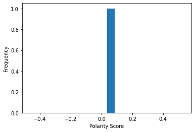

```python
# Extracting paragraphs
paragraphs = []
for paragraph in soup.find_all('p'):
    paragraphs.append(paragraph.text.strip())

# Concatenating paragraphs into a single string
text = ' '.join(paragraphs)

# Preprocessing the text data
text = text.lower()
text = ''.join(c for c in text if c.isalnum() or c.isspace())
words = text.split()
stop_words = set(stopwords.words('english'))
words = [word for word in words if word not in stop_words]

# Performing sentiment analysis
blob = TextBlob(text)
polarity_scores = [sentence.sentiment.polarity for sentence in blob.sentences]

# Visualizing the results
plt.hist(polarity_scores, bins=20)
plt.xlabel('Polarity Score')
plt.ylabel('Frequency')
plt.show()
```

This cell analyzes the sentiment of the text data, creates a histogram plot of the distribution of polarity scores, and prints statistics about the number of words, sentences, average sentence length, and maximum sentence length.

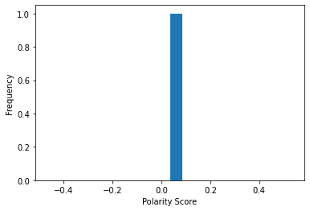

```
Number of words: 13509
Number of sentences: 1
Average sentence length: 13509.0
Maximum sentence length: 21270
```

```python
# Extracting paragraphs
paragraphs = []
for paragraph in soup.find_all('p'):
    paragraphs.append(paragraph.text.strip())

# Concatenating paragraphs into a single string
text = ' '.join(paragraphs)

# Preprocessing the text data
text = text.lower()
text = ''.join(c for c in text if c.isalnum() or c.isspace())
words = text.split()
stop_words = set(stopwords.words('english'))
words = [word for word in words if word not in stop_words]

# Analyzing the sentiment of the text data
blob = TextBlob(text)
polarity_scores = [sentence.sentiment.polarity for sentence in blob.sentences]

# Visualizing the distribution of polarity scores
plt.hist(polarity_scores, bins=20)
plt.xlabel('Polarity Score')
plt.ylabel('Frequency')
plt.show()

# Displaying statistics of the data
print('Number of words:', len(words))
print('Number of sentences:', len(blob.sentences))
print('Average sentence length:', len(words) / len(blob.sentences))
print('Maximum sentence length:', max(len(sentence.split()) for sentence in blob.sentences))
```